# HW3

This author section should be left blank empty for anonymous grading

Due 2024-02-15

## Instruction:

Once you have completed your answer, please submit both the knitted .html file and the .rmd file together.

### Question 1: Write your code in the code chunk and your text answer after the code chunk.

```r
# Import the data set
advertising <- read.csv("datasets/advertising.csv")

# Get correlation matrix
correlation_matrix <- cor(advertising)
correlation_matrix
```

```
##                     X         TV       radio   newspaper       sales
## X          1.00000000 0.01771469 -0.11068044 -0.15494414 -0.05161625
## TV         0.01771469 1.00000000  0.05480866  0.05664787  0.78222442
## radio     -0.11068044 0.05480866  1.00000000  0.35410375  0.57622257
## newspaper -0.15494414 0.05664787  0.35410375  1.00000000  0.22829903
## sales     -0.05161625 0.78222442  0.57622257  0.22829903  1.00000000
```

For the three predictors, `radio` and `newspaper` have the strongest linear association, with a correlation coefficient of 0.3541038.

`TV` has the strongest linear relationship with `sales`. The correlation coefficient is 0.7822244.

### Question 2: Write your code in the code chunk and your text answer after the code chunk.

```r
lm.sales_on_newspaper_TV <- lm(sales ~ newspaper + TV, data = advertising)

lm.sales_on_newspaper_radio_TV <- lm(
  sales ~ newspaper + radio + TV,
  data = advertising
)

lm.sales_on_newspaper_TV
```

```
##
## Call:
## lm(formula = sales ~ newspaper + TV, data = advertising)
##
## Coefficients:
## (Intercept)    newspaper           TV
##     5.77495      0.04422      0.04690
```

```r
lm.sales_on_newspaper_radio_TV
```

```
##
## Call:
## lm(formula = sales ~ newspaper + radio + TV, data = advertising)
##
## Coefficients:
## (Intercept)    newspaper        radio           TV
##    2.938889    -0.001037     0.188530     0.045765
```

The signs of the partial coefficients of `newspaper` are different for the two models. One possible reason why is that `newspaper` may not be independent of `radio`, i.e. there might be correlation between the two variables.

```r
summary(lm.sales_on_newspaper_radio_TV)
```

```
##
## Call:
## lm(formula = sales ~ newspaper + radio + TV, data = advertising)
##
## Residuals:
##     Min      1Q  Median      3Q     Max
## -8.8277 -0.8908  0.2418  1.1893  2.8292
##
## Coefficients:
##              Estimate Std. Error t value Pr(>|t|)
## (Intercept)  2.938889   0.311908   9.422   <2e-16 ***
## newspaper   -0.001037   0.005871  -0.177     0.86
## radio        0.188530   0.008611  21.893   <2e-16 ***
## TV           0.045765   0.001395  32.809   <2e-16 ***
## ---
## Signif. codes:  0 '***' 0.001 '**' 0.01 '*' 0.05 '.' 0.1 ' ' 1
##
## Residual standard error: 1.686 on 196 degrees of freedom
## Multiple R-squared:  0.8972, Adjusted R-squared:  0.8956
## F-statistic: 570.3 on 3 and 196 DF,  p-value: < 2.2e-16
```

H0: $\beta$<sub>newspaper</sub> = 0  
Ha: $\beta$<sub>newspaper</sub> != 0

The p-value for the coefficient $\beta$<sub>newspaper</sub> is 0.8599151, which is above 0.05. So we fail to reject the null hypothesis, meaning that we fail to prove that the variable `newspaper` is statistically significant to the model.

### Question 3: Write your code in the code chunk and your text answer after the code chunk.

```r
lm.sales_on_radio <- lm(sales ~ radio, data = advertising)

lm.tv_on_radio <- lm(TV ~ radio, data = advertising)

plot(lm.sales_on_radio$residuals ~ lm.tv_on_radio$residuals)

lm.regression_residuals <- lm(
  lm.sales_on_radio$residuals ~ lm.tv_on_radio$residuals
)

summary(lm.regression_residuals)
```

```
##
## Call:
## lm(formula = lm.sales_on_radio$residuals ~ lm.tv_on_radio$residuals)
##
## Residuals:
##     Min      1Q  Median      3Q     Max
## -8.7977 -0.8752  0.2422  1.1708  2.8328
##
## Coefficients:
##                            Estimate Std. Error t value Pr(>|t|)
## (Intercept)              -1.959e-16  1.186e-01    0.00        1
## lm.tv_on_radio$residuals  4.575e-02  1.387e-03   32.99   <2e-16 ***
## ---
## Signif. codes:  0 '***' 0.001 '**' 0.01 '*' 0.05 '.' 0.1 ' ' 1
##
## Residual standard error: 1.677 on 198 degrees of freedom
## Multiple R-squared:  0.8461, Adjusted R-squared:  0.8453
## F-statistic:  1088 on 1 and 198 DF,  p-value: < 2.2e-16
```

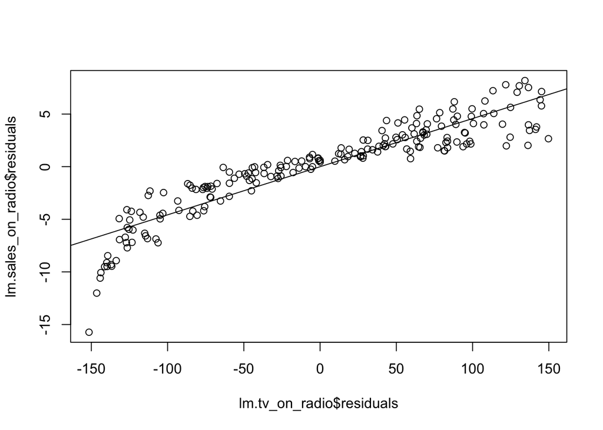

```
## integer(0)
```

```r
plot(lm.sales_on_radio$residuals ~ lm.tv_on_radio$residuals) +
  abline(
    lm.regression_residuals$coefficients[1],
    lm.regression_residuals$coefficients[2]
  )
```

$beta$<sub>1</sub> for the regression line for this partial regression plot is 0.0457548, and the p-value for this slope is 2.1276199^{-82}, which is less than 0.05, so the predictor `TV` is statistically significant, and should be included in the model.

### Question 4: Write your code in the code chunk and your text answer after the code chunk.

```r
lm.sales_on_radio_TV <- lm(sales ~ radio + TV, data = advertising)
summary(lm.sales_on_radio_TV)
```

```
##
## Call:
## lm(formula = sales ~ radio + TV, data = advertising)
##
## Residuals:
##     Min      1Q  Median      3Q     Max
## -8.7977 -0.8752  0.2422  1.1708  2.8328
##
## Coefficients:
##             Estimate Std. Error t value Pr(>|t|)
## (Intercept)  2.92110    0.29449   9.919   <2e-16 ***
## radio        0.18799    0.00804  23.382   <2e-16 ***
## TV           0.04575    0.00139  32.909   <2e-16 ***
## ---
## Signif. codes:  0 '***' 0.001 '**' 0.01 '*' 0.05 '.' 0.1 ' ' 1
##
## Residual standard error: 1.681 on 197 degrees of freedom
## Multiple R-squared:  0.8972, Adjusted R-squared:  0.8962
## F-statistic: 859.6 on 2 and 197 DF,  p-value: < 2.2e-16
```

```r
summary(lm.sales_on_radio)
```

```
##
## Call:
## lm(formula = sales ~ radio, data = advertising)
##
## Residuals:
##      Min       1Q   Median       3Q      Max
## -15.7305  -2.1324   0.7707   2.7775   8.1810
##
## Coefficients:
##             Estimate Std. Error t value Pr(>|t|)
## (Intercept)  9.31164    0.56290  16.542   <2e-16 ***
## radio        0.20250    0.02041   9.921   <2e-16 ***
## ---
## Signif. codes:  0 '***' 0.001 '**' 0.01 '*' 0.05 '.' 0.1 ' ' 1
##
## Residual standard error: 4.275 on 198 degrees of freedom
## Multiple R-squared:  0.332,  Adjusted R-squared:  0.3287
## F-statistic: 98.42 on 1 and 198 DF,  p-value: < 2.2e-16
```

The R<sup>2</sup> for the regression of `sales` on `radio` *and* `TV` is 0.8971943, which is more than the R<sup>2</sup> for the regression of `sales` on `radio`: 0.3320325.

The same holds true for the adjusted R<sup>2</sup>. The adjusted R<sup>2</sup> for the regression of `sales` on `radio` *and* `TV` is 0.8961505, which is more than the adjusted R<sup>2</sup> for the regression of `sales` on `radio`: 0.3286589.

These statistics validate our choice in question (3), providing additional support to our decision to include the predictor `TV` in the model.

### Question 5: Write your code in the code chunk and your text answer after the code chunk.

```r
summary(lm.sales_on_radio_TV)
```

```
##
## Call:
## lm(formula = sales ~ radio + TV, data = advertising)
##
## Residuals:
##     Min      1Q  Median      3Q     Max
## -8.7977 -0.8752  0.2422  1.1708  2.8328
##
## Coefficients:
##             Estimate Std. Error t value Pr(>|t|)
## (Intercept)  2.92110    0.29449   9.919   <2e-16 ***
## radio        0.18799    0.00804  23.382   <2e-16 ***
## TV           0.04575    0.00139  32.909   <2e-16 ***
## ---
## Signif. codes:  0 '***' 0.001 '**' 0.01 '*' 0.05 '.' 0.1 ' ' 1
##
## Residual standard error: 1.681 on 197 degrees of freedom
## Multiple R-squared:  0.8972, Adjusted R-squared:  0.8962
## F-statistic: 859.6 on 2 and 197 DF,  p-value: < 2.2e-16
```

Hypothesis test:  
H0: $\beta$<sub>radio</sub> = $\beta$<sub>TV</sub> = 0  
Ha: $\beta$<sub>radio</sub> != 0 AND/OR $\beta$<sub>TV</sub> != 0

The F-statistic is 859.6177183, and the p-value for it is < 2.2{-16}, which is less that 0.05. So at a 95% confidence level, we reject the null hypothesis, meaning that the model is significant.

The partial regression coefficient of `radio` is 0.1879942, which means that when `TV` is held constant, for every 1 unit increase in radio advertising, there is a 0.1879942 unit increase in sales.

### Question 6: Write your code in the code chunk and your text answer after the code chunk.

```r
lm.reduced <- lm.sales_on_radio_TV
lm.full <- lm(sales ~ radio + TV + TV:radio, data = advertising)
```

The R<sup>2</sup> for the regression of `sales` on `radio` and `TV` is 0.8971943, which is less than the R<sup>2</sup> for the regression of `sales` on `radio` and `TV` and the interaction term between `TV` and `radio`: 0.9677905.

The same holds true for the adjusted R<sup>2</sup>. The adjusted R<sup>2</sup> for the regression of `sales` on `radio` and `TV` is 0.8961505, which is less than the adjusted R<sup>2</sup> for the regression of `sales` on `radio` and `TV` and the interaction term between `TV` and `radio`: 0.9672975.

These statistics provide evidence that the second model (the one that includes `TV:radio`) is better.

F test:

H0: $\beta$<sub>`TV:radio`</sub> = 0 Ha: $\beta$<sub>`TV:radio`</sub> != 0

```r
anova <- anova(lm.reduced, lm.full)
anova
```

```
## Analysis of Variance Table
##
## Model 1: sales ~ radio + TV
## Model 2: sales ~ radio + TV + TV:radio
##   Res.Df    RSS Df Sum of Sq      F    Pr(>F)
## 1    197 556.91
## 2    196 174.48  1    382.43 429.59 < 2.2e-16 ***
## ---
## Signif. codes:  0 '***' 0.001 '**' 0.01 '*' 0.05 '.' 0.1 ' ' 1
```

The f-statistic is 429.5904628 and the p-value is 2.757681^{-51}, which is less than 0.05, so we can reject the null hypothesis. This means we should include the interaction term `TV:radio` in the model.